# usage_demo

###### This Python module is designed to help automate the extraction of WB projects sector codes and theme codes data.

###### The following is a brief demo explaining the some functionalities and possible use cases of the module.

###### Note: To use the module, access to IEG N-Drive is required. Additionally, for smooth functionality, it is advised that the directory in which this module is located be made the current working directory while using the module.

### SECTOR CODES

##### To extract sector codes, user must first create a Sectors object and load this object with the WB project sectors data.

```python
#Import the Sectors object
from proj_codes import Sectors

#Create a Sectors object.
sector_demo = Sectors()     #Users can give the object any name; "sector_demo" is used only for illustration.
```

```
Sectors object created.
```

```python
#Load project sector codes data into the object created
sector_demo.load_data()
```

```
Loading WB project sectors data.
This typically takes between 1-3 minutes. Please wait...
Data loading successful!
Loaded data contains 163771 rows and 82158 unique WB projects.
Total loading time: 41.1 seconds.
Data source: World Bank PowerBI Data Platform.
Data download date: April 14, 2022.
```

###### Once the data is loaded successfully, user will see some information about the source of the data and the date the data was downloaded from this source. The data loaded into the Sectors object represents all of the WB projects sector data available from the data source as of the download date indicated.

###### From here, there are typically two use-cases.

###### USE-CASE 1: User has Project IDs and wishes to extract sector codes to which these projects are mapped.

```python
#Suppose these are the PIDs whose sector codes user wishes to extract.
my_PIDs = ['P115608', 'P115426']

#The get_sectors method will return the sector codes that the PIDs are mapped to. Note, PIDs must be supplied as a list.
sector_demo.get_sectors(my_PIDs)
```

```
Sector codes found for 2 out of 2 requested projects.
```

|  | Project Id | Major Sector Code | Major Sector Long Name | Sector Code | Sector Long Name | Sector Percentage |
| --- | --- | --- | --- | --- | --- | --- |
| 0 | P115426 | LX | Energy and Extractives | LZ | Other Energy and Extractives | 100.0 |
| 1 | P115608 | LX | Energy and Extractives | LB | Renewable Energy Biomass | 13.0 |
| 2 | P115608 | LX | Energy and Extractives | LI | Renewable Energy Geothermal | 13.0 |
| 3 | P115608 | LX | Energy and Extractives | LU | Renewable Energy Solar | 13.0 |
| 4 | P115608 | LX | Energy and Extractives | LW | Renewable Energy Wind | 13.0 |
| 5 | P115608 | TX | Transportation | TC | Urban Transport | 48.0 |

```python
#Set the show_meta argument to True to see additional more project level information for each project
sector_demo.get_sectors(pids=my_PIDs,
                        show_meta=True)
```

```
Sector codes found for 2 out of 2 requested projects.
```

|  | Project Id | Major Sector Code | Major Sector Long Name | Sector Code | Sector Long Name | Sector Percentage | Project Display Name | Project Approval FY | Approval Date | Country Short Name | ... | Project Status Name | Lead GP/Global Themes | Lending Instrument Long Name | Additional Financing Flag | Project Closing Cancellation Date | Project Closing Cancellation Status Code | Project Grant Commitments | Project IDA Commitments | Project IBRD Commitments | Project Total Commitments |
| --- | --- | --- | --- | --- | --- | --- | --- | --- | --- | --- | --- | --- | --- | --- | --- | --- | --- | --- | --- | --- | --- |
| 0 | P115426 | LX | Energy and Extractives | LZ | Other Energy and Extractives | 100.0 | ENERGY EFFICIENCY DPL | 2011.0 | 2011-06-06 | Poland | ... | Closed | Energy & Extractives | Development Policy Lending | NaN | NaT | NaN | NaN | NaN | NaN | 0.0 |
| 1 | P115608 | LX | Energy and Extractives | LB | Renewable Energy Biomass | 13.0 | MX Framework for Green Growth DPL | 2010.0 | 2009-10-19 | Mexico | ... | Closed | Energy & Extractives | Development Policy Lending | NaN | NaT | NaN | NaN | NaN | NaN | 0.0 |
| 2 | P115608 | LX | Energy and Extractives | LI | Renewable Energy Geothermal | 13.0 | MX Framework for Green Growth DPL | 2010.0 | 2009-10-19 | Mexico | ... | Closed | Energy & Extractives | Development Policy Lending | NaN | NaT | NaN | NaN | NaN | NaN | 0.0 |
| 3 | P115608 | LX | Energy and Extractives | LU | Renewable Energy Solar | 13.0 | MX Framework for Green Growth DPL | 2010.0 | 2009-10-19 | Mexico | ... | Closed | Energy & Extractives | Development Policy Lending | NaN | NaT | NaN | NaN | NaN | NaN | 0.0 |
| 4 | P115608 | LX | Energy and Extractives | LW | Renewable Energy Wind | 13.0 | MX Framework for Green Growth DPL | 2010.0 | 2009-10-19 | Mexico | ... | Closed | Energy & Extractives | Development Policy Lending | NaN | NaT | NaN | NaN | NaN | NaN | 0.0 |
| 5 | P115608 | TX | Transportation | TC | Urban Transport | 48.0 | MX Framework for Green Growth DPL | 2010.0 | 2009-10-19 | Mexico | ... | Closed | Energy & Extractives | Development Policy Lending | NaN | NaT | NaN | NaN | NaN | NaN | 0.0 |

6 rows × 23 columns

```python
#Use save_last to save the output returned.
#The optional save_name argument lets user specify the name the output should be saved with
sector_demo.save_last(save_name="sector_demo")
```

```
Output saved.
```

##### USE CASE 2: User has Sector Codes and wishes to extract projects mapped to those sector codes.

```python
#Suppose the sector codes of interest are those shown below.
my_codes = ['TC', 'TP']

#The get_projects method will return the projects mapped to these sector codes. Note: sector codes must be supplied as a list.
sector_demo.get_projects(sector_codes=my_codes)
```

```
1149 unique projects found.
```

|  | Project Id | Sector Code | Sector Long Name | Sector Percentage | Additional Financing Flag | Project Approval FY | Project Status Name | Product Line Type | Lead GP/Global Themes |
| --- | --- | --- | --- | --- | --- | --- | --- | --- | --- |
| 0 | P000034 | TP | Ports/Waterways | 18.0 | NaN | 1992.0 | Closed | L | Transport |
| 1 | P000050 | TP | Ports/Waterways | 13.0 | NaN | 1993.0 | Closed | L | Transport |
| 2 | P000117 | TP | Ports/Waterways | 13.0 | NaN | 1997.0 | Closed | L | Transport |
| 3 | P000435 | TP | Ports/Waterways | 53.0 | NaN | 1993.0 | Closed | L | Transport |
| 4 | P000438 | TP | Ports/Waterways | 2.0 | NaN | 1996.0 | Closed | L | Finance, Competitiveness and Innovation |
| ... | ... | ... | ... | ... | ... | ... | ... | ... | ... |
| 1174 | P175266 | TC | Urban Transport | 60.0 | NaN | 2022.0 | Active | L | Urban, Resilience and Land |
| 1175 | P176094 | TC | Urban Transport | 73.0 | Y | 2022.0 | Active | L | Social Sustainability and Inclusion |
| 1176 | P176208 | TC | Urban Transport | 53.0 | NaN | 2022.0 | Active | L | Transport |
| 1177 | P176208 | TP | Ports/Waterways | 19.0 | NaN | 2022.0 | Active | L | Transport |
| 1178 | P177931 | TP | Ports/Waterways | 20.0 | NaN | 2022.0 | Active | L | Macroeconomics, Trade and Investment |

1179 rows × 9 columns

The output has 1179 rows of data even though there are only 1149 unique projects. This is because some of those 1149 projects are mapped to both sectors codes, and thus are returned twice, each row indicating unique project ID-sector code combination.

Note that these 1149 projects are the projects where one or more of the sector codes provided account for at least 1% of the project. User can adjust this sector percentage threshold by setting the optional min_pct argument.

User can also customize the data extract by setting several other additional arguments. Example is shown below, but full usage information is available in the documentation for the get_project command.

```python
sector_demo.get_projects(sector_codes=my_codes,
                        min_pct=80,                 #Only return projects where any code in sector_codes account for 80% or more
                        start_FY=2000,              #Only return projects approved after FY2000
                        stop_FY=2010,               #Only return projects approved before FY2010
                        product_type=['L'],         #Only return lending projects
                        project_status=['closed'],  #Only return closed projects
                        include_AF=False)           #Do not include Additional Financing projects in the output
```

```
20 unique projects found.
```

|  | Project Id | Sector Code | Sector Long Name | Sector Percentage | Additional Financing Flag | Project Approval FY | Project Status Name | Product Line Type | Lead GP/Global Themes |
| --- | --- | --- | --- | --- | --- | --- | --- | --- | --- |
| 0 | P008615 | TP | Ports/Waterways | 100.0 | NaN | 2001.0 | Closed | L | Transport |
| 1 | P034038 | TC | Urban Transport | 94.0 | NaN | 2002.0 | Closed | L | Transport |
| 2 | P035776 | TP | Ports/Waterways | 100.0 | NaN | 2000.0 | Closed | L | Transport |
| 3 | P068133 | TP | Ports/Waterways | 80.0 | NaN | 2006.0 | Closed | L | Transport |
| 4 | P076822 | TP | Ports/Waterways | 100.0 | NaN | 2002.0 | Closed | L | Urban, Resilience and Land |
| 5 | P081615 | TC | Urban Transport | 97.0 | NaN | 2010.0 | Closed | L | Transport |
| 6 | P082412 | TC | Urban Transport | 100.0 | NaN | 2006.0 | Closed | L | Transport |
| 7 | P082466 | TC | Urban Transport | 90.0 | NaN | 2004.0 | Closed | L | Transport |
| 8 | P083581 | TC | Urban Transport | 84.0 | NaN | 2008.0 | Closed | L | Transport |
| 9 | P093767 | TP | Ports/Waterways | 95.0 | NaN | 2007.0 | Closed | L | Transport |
| 10 | P095485 | TC | Urban Transport | 80.0 | NaN | 2010.0 | Closed | L | Transport |
| 11 | P099992 | TC | Urban Transport | 86.0 | NaN | 2006.0 | Closed | L | Transport |
| 12 | P101456 | TP | Ports/Waterways | 84.0 | NaN | 2007.0 | Closed | L | Transport |
| 13 | P102365 | TP | Ports/Waterways | 93.0 | NaN | 2009.0 | Closed | L | Transport |
| 14 | P106038 | TC | Urban Transport | 99.0 | NaN | 2008.0 | Closed | L | Transport |
| 15 | P106471 | TP | Ports/Waterways | 80.0 | NaN | 2007.0 | Closed | L | Transport |
| 16 | P107159 | TC | Urban Transport | 97.0 | NaN | 2010.0 | Closed | L | Transport |
| 17 | P110371 | TC | Urban Transport | 100.0 | NaN | 2010.0 | Closed | L | Transport |
| 18 | P111421 | TC | Urban Transport | 99.0 | NaN | 2010.0 | Closed | L | Transport |
| 19 | P112838 | TC | Urban Transport | 87.0 | NaN | 2010.0 | Closed | L | Transport |

```
Plot saved.
```

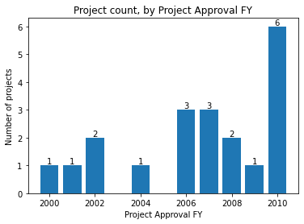

```python
#Use plot_fy to get a quick look of the FY distribution of the projects returned by the last .get_projects command.
sector_demo.plot_fy(save_it=True)
```

```
Plot saved.
```

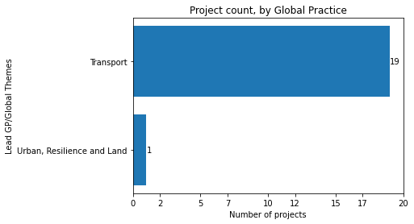

```python
#Use plot_gp to get a quick look of the distribution by Global Practice of the projects returned by the last .get_projects command.
#The plot_gp command accepts optional arguments (save_it and save_name) to save the plot created.
sector_demo.plot_gp(save_it=True, save_name="GP_dist")
```

```python
#For more information about other methods and functionalities of a Sectors object, use the help command.
help(Sectors)
```

```
Help on class Sectors in module proj_codes:

class Sectors(builtins.object)
 |  Methods defined here:
 |  __init__(self)
 |      Initialize self.  See help(type(self)) for accurate signature.
 |  copy_data(self)
 |      Description
 |      ----------
 |      Returns a copy of the DataFrame, if any, that has been loaded into the data attribute of a Sectors object.
 |      Supports variable assignment.
 |      Parameters
 |      ----------
 |      None
 |      Returns
 |      ----------
 |      DataFrame object
 |  data_info(self)
 |      Description
 |      ----------
 |      Prints summary information on the DataFrame, if any, that has been loaded into the data attribute of a Sectors object.
 |      Variable assignment not supported.
 |      Parameters
 |      ----------
 |      None
 |      Returns
 |      ----------
 |      None
 |  get_projects(self, sector_codes, min_pct=1, start_FY=None, stop_FY=None, product_type=None, project_status=None, include_AF=True, show_all=False, show_meta=False)
 |      Description
 |      ----------
 |      Returns projects that are mapped to the specified sector codes and that satisfy other optional criteria.
 |      Supports a variable assignment.
 |      Data must already be loaded into the Sectors object.
 |      Parameters
 |      ----------
 |      sector_codes : list
 |          Returned projects must be mapped to one or more sector codes in sector_codes.
 |          Only sub-sector level codes are accepted.
 |      min_pct : int, default 1
```

[output cut: 119 more lines]

```
 |      ----------
 |      Deletes the DataFrame, if any, that has been loaded into the data attribute of a Sectors object.
 |      Data unloading occurs in place and does not support variable assignment.
 |      Parameters
 |      ----------
 |      None
 |      Returns
 |      ----------
 |      None
 |  ----------------------------------------------------------------------
 |  Data descriptors defined here:
 |  __dict__
 |      dictionary for instance variables (if defined)
 |  __weakref__
 |      list of weak references to the object (if defined)
```

### THEME CODES

```python
#The syntax for extracting theme codes is similar to that of sector codes.
#Only difference is to replace sectors with themes.
from proj_codes import Themes
theme_data = Themes()
```

```
Themes object created.
```

```python
theme_data.load_data()
```

```
Loading WB project Themes data.
This typically takes between 2-5 minutes. Please wait...
Data loading successful!
Loaded data contains 646921 rows and 74939 unique WB projects.
Total loading time: 74.9 seconds.
Data source: World Bank PowerBI Data Platform.
Data download date: April 14, 2022.
```

###### USE CASE 1: USER HAS PROJECT IDs AND IS LOOKING TO EXTRACT THAT THEME CODES THAT THE PROJECTS ARE MAPPED TO

```python
PIDs_of_interest = ['P115608', 'P115426', 'P124006', 'P144774']
theme_data.get_themes(PIDs_of_interest, show_meta=False)
```

```
Theme codes found for 4 out of 4 requested projects.
```

|  | Project Id | Theme Code | Theme Name | Theme Percentage |
| --- | --- | --- | --- | --- |
| 0 | P115426 | 80 | Environment and Natural Resource Management | 101.0 |
| 1 | P115426 | 81 | Climate change | 92.0 |
| 2 | P115426 | 82 | Environmental Health and Pollution Management | 9.0 |
| 3 | P115426 | 811 | Mitigation | 92.0 |
| 4 | P115426 | 821 | Air quality management | 3.0 |
| 5 | P115426 | 822 | Water Pollution | 3.0 |
| 6 | P115426 | 823 | Soil Pollution | 3.0 |
| 7 | P115608 | 10 | Economic Policy | 26.0 |
| 8 | P115608 | 20 | Private Sector Development | 13.0 |
| 9 | P115608 | 60 | Human Development and Gender | 13.0 |
| 10 | P115608 | 70 | Urban and Rural Development | 25.0 |
| 11 | P115608 | 80 | Environment and Natural Resource Management | 25.0 |
| 12 | P115608 | 11 | Fiscal Policy | 13.0 |
| 13 | P115608 | 13 | Economic Growth and Planning | 13.0 |
| 14 | P115608 | 22 | Jobs | 13.0 |
| 15 | P115608 | 66 | Labor Market Policy and Programs | 13.0 |
| 16 | P115608 | 71 | Urban Development | 25.0 |
| 17 | P115608 | 81 | Climate change | 25.0 |
| 18 | P115608 | 115 | Subnational Fiscal Policies | 13.0 |
| 19 | P115608 | 135 | Migration, Remittances and Diaspora Engagement | 13.0 |
| 20 | P115608 | 223 | Youth Employment | 13.0 |
| 21 | P115608 | 662 | Labor Market Institutions | 13.0 |
| 22 | P115608 | 711 | Urban Infrastructure and Service Delivery | 25.0 |
| 23 | P115608 | 811 | Mitigation | 25.0 |
| 24 | P124006 | 10 | Economic Policy | 31.0 |
| 25 | P124006 | 20 | Private Sector Development | 27.0 |
| 26 | P124006 | 70 | Urban and Rural Development | 41.0 |
| 27 | P124006 | 14 | Trade | 31.0 |
| 28 | P124006 | 22 | Jobs | 14.0 |
| 29 | P124006 | 25 | Regional Integration | 13.0 |
| 30 | P124006 | 71 | Urban Development | 14.0 |
| 31 | P124006 | 72 | Rural Development | 27.0 |
| 32 | P124006 | 141 | Trade Facilitation | 31.0 |
| 33 | P124006 | 221 | Job Creation | 14.0 |
| 34 | P124006 | 711 | Urban Infrastructure and Service Delivery | 14.0 |
| 35 | P124006 | 723 | Rural Infrastructure and service delivery | 27.0 |
| 36 | P144774 | 10 | Economic Policy | 29.0 |
| 37 | P144774 | 20 | Private Sector Development | 19.0 |
| 38 | P144774 | 70 | Urban and Rural Development | 52.0 |
| 39 | P144774 | 14 | Trade | 29.0 |
| 40 | P144774 | 22 | Jobs | 9.0 |
| 41 | P144774 | 25 | Regional Integration | 10.0 |
| 42 | P144774 | 71 | Urban Development | 43.0 |
| 43 | P144774 | 72 | Rural Development | 9.0 |
| 44 | P144774 | 141 | Trade Facilitation | 29.0 |
| 45 | P144774 | 221 | Job Creation | 9.0 |
| 46 | P144774 | 711 | Urban Infrastructure and Service Delivery | 43.0 |
| 47 | P144774 | 723 | Rural Infrastructure and service delivery | 9.0 |

```python
# get_themes accepts an optional argument, theme_level, to specify the granularity level of the themes to be returned.
# Below, I am requesting for level 3 themes only. This is the most granular theme level.
# Higher level theme codes are represented with levels 1 and 2.
# See help(Themes.get_themes) for more information
theme_data.get_themes(PIDs_of_interest,
                      theme_level=[3],
                      show_meta=False)
```

```
Theme codes found for 4 out of 4 requested projects.
```

|  | Project Id | Theme Code | Theme Name | Theme Percentage |
| --- | --- | --- | --- | --- |
| 0 | P115426 | 811 | Mitigation | 92.0 |
| 1 | P115426 | 821 | Air quality management | 3.0 |
| 2 | P115426 | 822 | Water Pollution | 3.0 |
| 3 | P115426 | 823 | Soil Pollution | 3.0 |
| 4 | P115608 | 115 | Subnational Fiscal Policies | 13.0 |
| 5 | P115608 | 135 | Migration, Remittances and Diaspora Engagement | 13.0 |
| 6 | P115608 | 223 | Youth Employment | 13.0 |
| 7 | P115608 | 662 | Labor Market Institutions | 13.0 |
| 8 | P115608 | 711 | Urban Infrastructure and Service Delivery | 25.0 |
| 9 | P115608 | 811 | Mitigation | 25.0 |
| 10 | P124006 | 141 | Trade Facilitation | 31.0 |
| 11 | P124006 | 221 | Job Creation | 14.0 |
| 12 | P124006 | 711 | Urban Infrastructure and Service Delivery | 14.0 |
| 13 | P124006 | 723 | Rural Infrastructure and service delivery | 27.0 |
| 14 | P144774 | 141 | Trade Facilitation | 29.0 |
| 15 | P144774 | 221 | Job Creation | 9.0 |
| 16 | P144774 | 711 | Urban Infrastructure and Service Delivery | 43.0 |
| 17 | P144774 | 723 | Rural Infrastructure and service delivery | 9.0 |

##### USE CASE 2: USER HAS THEME CODES AND IS LOOKING TO EXTRACT PROJECTS MAPPED TO THOSE THEME CODES

```python
theme_data.get_projects(theme_codes=[811, 812],
                       start_FY=1995,
                       stop_FY=2010,
                       product_type=['A'],
                       project_status=['closed'],
                       include_AF=True)
```

```
418 unique projects found.
```

|  | Project Id | Theme Code | Theme Name | Theme Percentage | Project Approval FY | Project Status Name | Product Line Type | Additional Financing Flag | Lead GP/Global Themes |
| --- | --- | --- | --- | --- | --- | --- | --- | --- | --- |
| 0 | P051261 | 811 | Mitigation | 14.0 | 2004.0 | Closed | A | NaN | Environment, Natural Resources & the Blue Economy |
| 1 | P053645 | 811 | Mitigation | 25.0 | 1999.0 | Closed | A | NaN | Environment, Natural Resources & the Blue Economy |
| 2 | P055305 | 811 | Mitigation | 14.0 | 2002.0 | Closed | A | NaN | Water |
| 3 | P059153 | 811 | Mitigation | 13.0 | 2003.0 | Closed | A | NaN | Energy & Extractives |
| 4 | P062350 | 811 | Mitigation | 34.0 | 2000.0 | Closed | A | NaN | Environment, Natural Resources & the Blue Economy |
| ... | ... | ... | ... | ... | ... | ... | ... | ... | ... |
| 413 | P122058 | 811 | Mitigation | 30.0 | 2010.0 | Closed | A | NaN | Urban, Resilience and Land |
| 414 | P122286 | 811 | Mitigation | 50.0 | 2010.0 | Closed | A | NaN | Other |
| 415 | P122379 | 811 | Mitigation | 100.0 | 2010.0 | Closed | A | NaN | Other |
| 416 | P122385 | 811 | Mitigation | 50.0 | 2010.0 | Closed | A | NaN | Environment, Natural Resources & the Blue Economy |
| 417 | P122693 | 811 | Mitigation | 100.0 | 2010.0 | Closed | A | NaN | Energy & Extractives |

418 rows × 9 columns

```python
theme_data.save_last()
```

```
Output saved.
```

```
WARNING! 6 project(s) with missing GP data got excluded from the plot.
Plot saved.
```

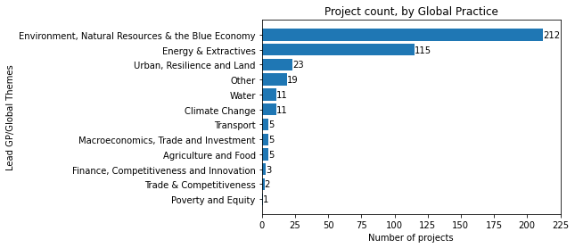

```python
theme_data.plot_gp(save_it=True, save_name="themes_gp_plot")
```

```
WARNING! 2 project(s) with missing Approval FY data got excluded from the plot.
```

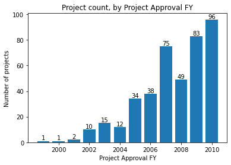

```python
theme_data.plot_fy(save_it=False)
```

```python
theme_data.save_last()
```

```
Output saved.
```